# Case Study

How to boost membership sign-ups in a bike-sharing company

Luís Costa

2024-03-22

### **Introduction**

Cyclistic, a Chicago-based bike-sharing company, has identified that enhancing membership sign-ups is paramount for driving company growth and value. Our objective is to explore into data analysis to comprehend the process of transitioning “casual” users into “member” users.

### **Problem Statement**

Cyclistic has experienced significant growth since its successful launch of bike-sharing services in 2016, expanding to a fleet of 5,824 bikes across 692 stations in Chicago.

While the company’s marketing strategy has focused on broad consumer awareness and flexible pricing plans, financial analysis reveals that **annual members yield higher profitability compared to casual riders.**

The Cyclistic’s marketing team, recognizing the potential for increased revenue through membership conversions, requires a deeper understanding of the differences between annual members and casual riders, the motivations driving casual riders to consider membership, and the impact of digital media on marketing tactics.

By leveraging historical bike ride data, Cyclistic seek to identify trends and insights to inform their marketing team approach and effectively convert casual riders into loyal annual members.

### **Methodology**

##### **Data Preparation**

- Obtain historical bike trip data from Cyclistic for the past 3 months.
- Verify the integrity and credibility of the data, assessing factors such as reliability, originality, comprehensiveness, and currency.
- Download and store the data securely for analysis.

##### **Data Processing:**

- Utilize appropriate tools for data processing, considering factors such as efficiency, compatibility, and functionality.
- Ensure data integrity by verifying for errors or inconsistencies.
- Cleanse and preprocess the data to remove duplicates, outliers, and irrelevant information.
- Document the data cleaning process, including steps taken and rationale behind decisions made, for transparency and reproducibility.

##### **Analysis:**

- Employ statistical and analytical techniques to explore the data and uncover trends, patterns, and insights.
- Segment the data based on customer types (casual riders vs. annual members) to compare usage patterns and behaviors.
- Analyze factors influencing customer conversion from casual riders to annual members, such as usage frequency, trip duration, and preferred stations.
- Visualize findings using charts, graphs, and other visual aids to enhance understanding and facilitate decision-making.

##### **Interpretation and Reporting:**

- Summarize key findings related to customer behavior, preferences, and conversion drivers.
- Provide recommendations for targeted marketing strategies aimed at converting casual riders into annual members.
- Document the entire analytical process, including methodologies, assumptions, limitations, and recommendations, in a comprehensive report for stakeholders’ review and reference.

##### **Deliverables:**

- Analytical report summarizing key findings and recommendations for marketing strategy optimization.

#### **Data Description**

The provided dataset comprises bike ride records from Cyclistic, covering a period of the first three months of the year 2023. Each record includes the following attributes:

- **ride_id:** Unique identifier for each bike ride.
- **rideable_type:** Type of bike used for the ride (e.g., electric bike, classic bike).
- **started_at:** Timestamp indicating the start time of the ride.
- **ended_at:** Timestamp indicating the end time of the ride.
- **start_station_name:** Name of the station where the ride originated.
- **start_station_id:** Unique identifier for the starting station.
- **end_station_name:** Name of the station where the ride concluded.
- **end_station_id:** Unique identifier for the ending station.
- **start_lat:** Latitude of the starting station’s location.
- **start_lng:** Longitude of the starting station’s location.
- **end_lat:** Latitude of the ending station’s location.
- **end_lng:** Longitude of the ending station’s location.
- **member_casual:** Indicates whether the rider is a member (“member”) or a casual rider (“casual”).

The dataset provides comprehensive information about bike rides, including details on ride duration, starting and ending locations, bike type, and rider type (member or casual). The data is structured and suitable for analysis to uncover insights into rider behavior, preferences, and trends over this specified three-month period.

### **Data Preparation and Processing**

Loading libraries and data.

```r
library(readr)
library(dplyr)
library(tmap)
library(sf)
library(ggplot2)
library(lubridate)

Data_Jan <- read_csv("202301-divvy-tripdata.csv")
Data_Fev <- read_csv("202302-divvy-tripdata.csv")
Data_Mar <- read_csv("202303-divvy-tripdata.csv")
```

Merging the datasets together for analysis.

```r
df_Year<- rbind(Data_Jan, Data_Fev,Data_Mar)
```

Checking the nulls on the data.

```r
null_counts <- colSums(is.na(df_Year))
knitr::kable(null_counts)
```

|  | x |
| --- | --- |
| ride_id | 0 |
| rideable_type | 0 |
| started_at | 0 |
| ended_at | 0 |
| start_station_name | 88104 |
| start_station_id | 88236 |
| end_station_name | 93016 |
| end_station_id | 93157 |
| start_lat | 0 |
| start_lng | 0 |
| end_lat | 426 |
| end_lng | 426 |
| member_casual | 0 |

Removing null end_lat and end_lng rows since they have a low number of records.

```r
df_Year <- df_Year %>%
  arrange(started_at) %>%
  filter(!is.na(end_lat)) %>%
  filter(!is.na(end_lng))
```

#### **Feature engineering**

We created new columns to retrieve new interesting information that we can analyse later.

- **Trip_Duration_min:** Duration of the trip in minutes.
- **Hour:** Hour the trip started at.
- **Day_of_week:** Day of the week the Trip happened.

```r
df_Year$Trip_Duration_min <- as.numeric(difftime(df_Year$ended_at, df_Year$started_at, units = "mins"))
df_Year <- df_Year %>%
  mutate(across(c('Trip_Duration_min'), round, 1))
df_Year$Hour <- format(df_Year$started_at, format = "%H")
df_Year$Hour <- as.numeric(df_Year$Hour)
df_Year$Day_of_week <- wday(df_Year$started_at, label=TRUE)
```

Lets check the new columns.

```r
knitr::kable(head(df_Year[, c('started_at','Trip_Duration_min', 'Hour', 'Day_of_week')]))
```

| started_at | Trip_Duration_min | Hour | Day_of_week |
| --- | --- | --- | --- |
| 2023-01-01 00:01:58 | 0.7 | 0 | dom |
| 2023-01-01 00:02:06 | 27.7 | 0 | dom |
| 2023-01-01 00:03:26 | 4.0 | 0 | dom |
| 2023-01-01 00:04:07 | 9.8 | 0 | dom |
| 2023-01-01 00:04:27 | 12.4 | 0 | dom |
| 2023-01-01 00:04:54 | 27.0 | 0 | dom |

New columns look good for later analysis, lets now check the **outliers**.

#### **Outliers**

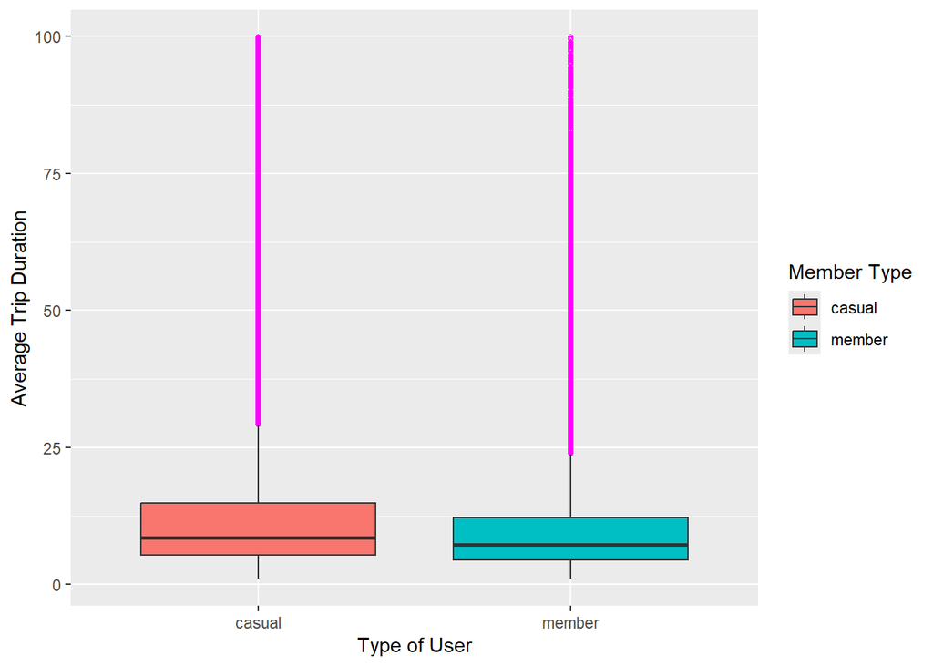

```r
df_Year <- df_Year %>%
  filter(Trip_Duration_min < 100) %>%
  filter(Trip_Duration_min >= 1)

g_boxplot <- ggplot(df_Year,  aes(x=member_casual, y=Trip_Duration_min,fill = member_casual)) +
  geom_boxplot(outlier.colour="magenta", outlier.shape=1,
               outlier.size=1, notch=FALSE) +
  labs(x = "Type of User", y = "Average Trip Duration") +
  scale_fill_discrete(name = "Member Type")

g_boxplot
```

With this Box plot, we can see the outliers detected with the magenta colored dots.Considering this, we decided that it would be a good decision to **remove** the trips with an average duration **larger than 30 minutes.**

```r
####Removing Outliers with a filter
df_Year <- df_Year %>%
  filter(Trip_Duration_min < 30) %>%
  filter(Trip_Duration_min >= 1)
```

### **Data Analysis and Findings**

#### **Average trip duration time**

Lets start by assessing the **average trip duration time** in minutes grouped by “Member Type”.

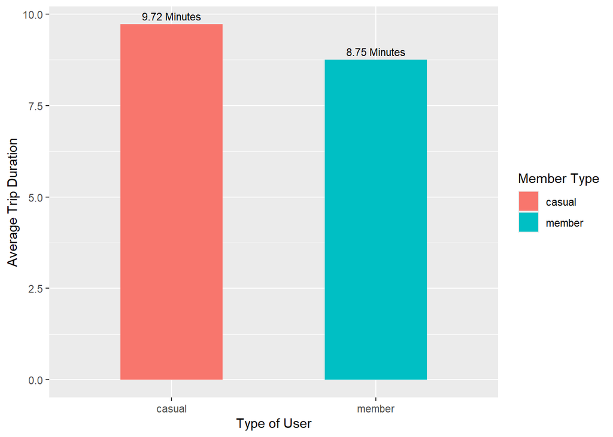

```r
df_trip_duration <- df_Year %>%
  group_by(member_casual) %>%
  summarise(avg_trip_duration = mean(Trip_Duration_min, na.rm = TRUE)) %>%
  mutate(across(c('avg_trip_duration'), round, 2))

####Plot
g_col <- ggplot(df_trip_duration,  aes(x=member_casual, y=avg_trip_duration,fill = member_casual)) +
  geom_col(width = 0.5) +
  geom_text(aes(label = sprintf("%.2f Minutes", avg_trip_duration)),
            position = position_dodge(width = 0.9),
            vjust = -0.5,
            size = 3) +
  labs(x = "Type of User", y = "Average Trip Duration") +
  scale_fill_discrete(name = "Member Type")
g_col
```

We can see that the “casual” bike users have a **larger** average trip duration time than the member users.

#### **Type of bikes**

Lets investigate the **type of bikes** the different users like to use.

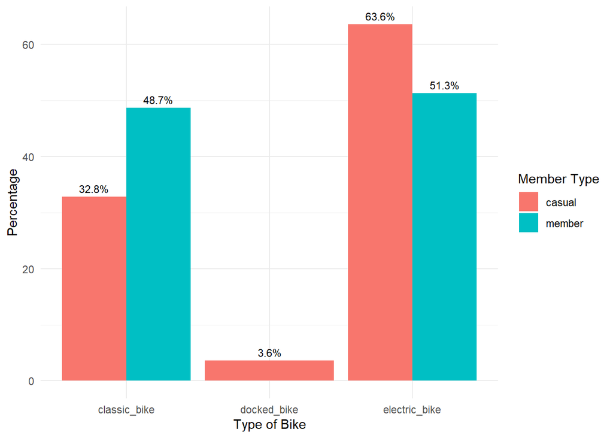

```r
df_Bikes <- df_Year %>%
  group_by(member_casual) %>%
  count(rideable_type) %>%
  mutate(Prcnt_Bike = n / sum(n) * 100) %>%
  rename(Sum_Bike = n) %>%
  mutate(across(c('Prcnt_Bike'), round, 1))

###Plot
g_bikeType <- ggplot(df_Bikes, aes(x = rideable_type, y = Prcnt_Bike, fill = member_casual)) +
  geom_bar(stat = "identity", position = "dodge") +
  geom_text(aes(label = sprintf("%.1f%%", Prcnt_Bike)),
            position = position_dodge(width = 0.9),
            vjust = -0.5,
            size = 3) +
  labs(x = "Type of Bike", y = "Percentage") +
  theme_minimal() +
  scale_fill_discrete(name = "Member Type")

g_bikeType
```

Here we can see that the “casual” users have a much **bigger** percentage of electric bike usage compared to the “member” users, which in turn have a very **balanced** use of either classic bike or electric bike.

#### **Hours of the Day with Greater bike usage**

Lets study the **Hours** of the day with Greater bike usage.

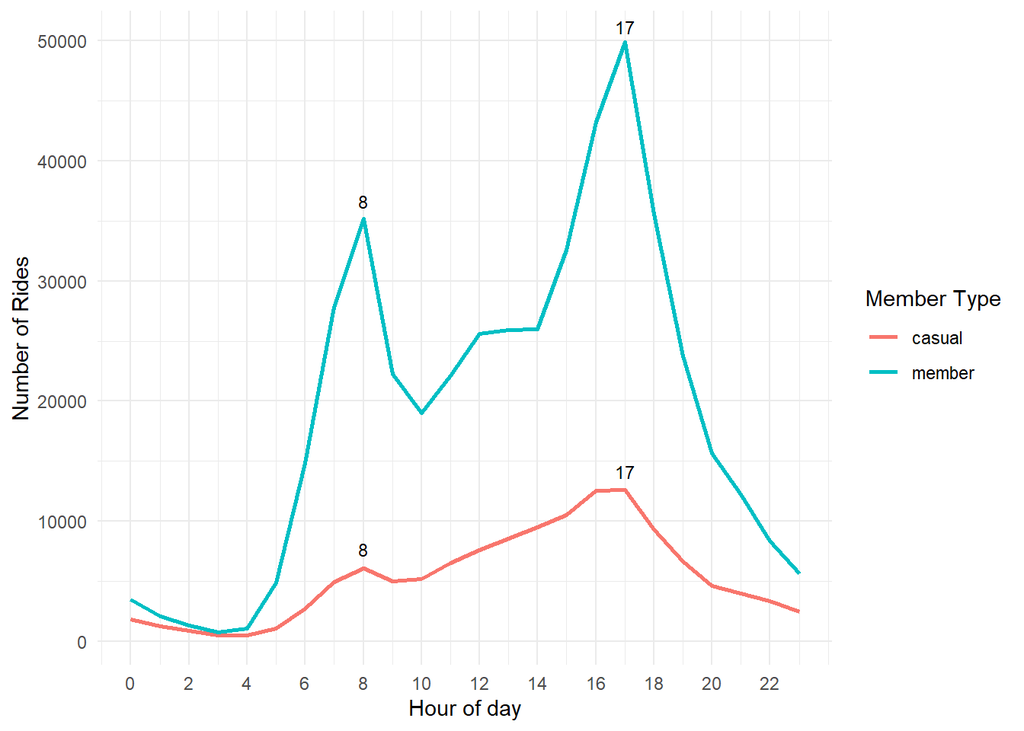

```r
df_Hours <- df_Year %>%
  group_by(member_casual) %>%
  count(Hour) %>%
  rename(Count_hour = n)


g_Hour <- ggplot(df_Hours, aes(x = Hour, y = Count_hour, color = member_casual)) +
  geom_line(size = 1) +
  labs(x = "Hour of day", y = "Number of Rides") +
  geom_text(data = data.frame(Hour = c(8, 17), Count_hour = c(35500, 50000)),
            aes(label = Hour),
            vjust = -0.5, size = 3, color = "black") +
  geom_text(data = data.frame(Hour = c(8, 17), Count_hour = c(6500, 13000)),
            aes(label = Hour),
            vjust = -0.5, size = 3, color = "black") +
  theme_minimal() +
  scale_x_continuous(breaks = seq(0, 23, by = 2), labels = seq(0, 23, by = 2)) +
  scale_color_discrete(name = "Member Type")

g_Hour
```

In this plot we can pinpoint at which hours occurs a **peak** in the use of bicycles, namely, there is greater use in the morning, around 8am and another peak at the end of the day, at 5pm.

#### **Days of the Week with Greater bike usage**

Lets examine in which days there is a greater number of rides.

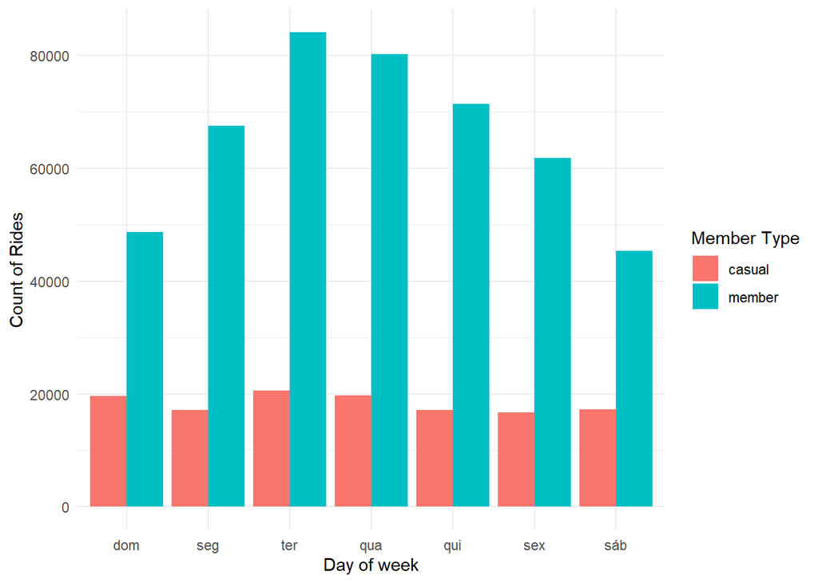

```r
df_DayOfweek <- df_Year %>%
  group_by(member_casual) %>%
  count(Day_of_week) %>%
  rename(Count_Days = n)

g_days <- ggplot(df_DayOfweek, aes(x = Day_of_week, y = Count_Days, fill = member_casual)) +
  geom_bar(stat = "identity", position = "dodge") +
  labs(x = "Day of week", y = "Count of Rides") +
  theme_minimal() +
  scale_fill_discrete(name = "Member Type")

g_days
```

On this plot we can infer that there is a greater usage of our service by the “member” users on the week days(seg,ter,qua,qui,sex) rather than on the weekend days(sáb,dom). The “casual” users show a similar count of rides on all the days.

#### **Trip duration per day of the week**

Lets dissect how the trip duration times difer over the week days.

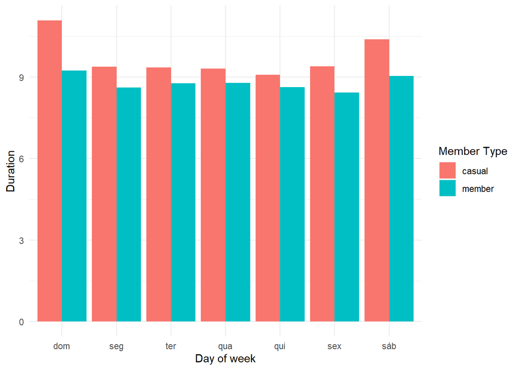

```r
df_Duration <- df_Year %>%
  group_by(Day_of_week,member_casual) %>%
  summarize(mean_Duration = mean(Trip_Duration_min))

g_Duration <- ggplot(df_Duration, aes(x = Day_of_week, y = mean_Duration, fill = member_casual)) +
  geom_bar(stat = "identity", position = "dodge") +
  labs(x = "Day of week", y = "Duration") +
  theme_minimal() +
  scale_fill_discrete(name = "Member Type")

g_Duration
```

We can observe that the “casual” users have a slightly bigger trip duration time in general over the “member” users. This difference is even bigger on the weekend days(sáb,dom).

#### **The 100th most used stations, a map view**

Lets see where our stations are mostly distributed over the city.

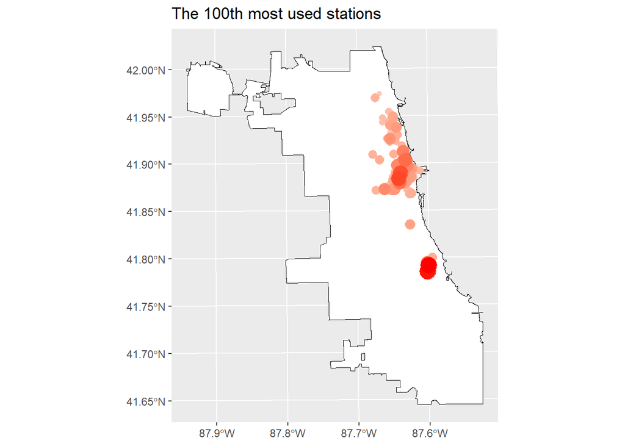

```r
#Creating a Data Frame with the 100th most used Starting Stations
df_starting_station_all <- df_Year %>%
  filter(!is.na(start_station_name)) %>%
  group_by(start_station_name) %>%
  count(start_station_name) %>%
  rename('Number_of_Trip_starts' = n) %>%
  arrange(Number_of_Trip_starts)%>%
  filter(Number_of_Trip_starts >= 1598 )

#Creating a Data Frame with the mean coords of the Starting stations and the merging the two Data Sets
df_coords<- df_Year %>%
  group_by(start_station_name) %>%
  summarize(mean_lon = mean(start_lng),
            mean_lat = mean(start_lat))

df_starting_station_all <- left_join(df_starting_station_all, df_coords, by = "start_station_name")

#Getting the map of Chicago from a .shp file
chicago <- st_read("cityboundary.shp")
#Converting the longitude and latitude points into usable map points with the "sf" library
df_points <- data.frame(
  lat = df_starting_station_all$mean_lat,  # example longitude values
  lon = df_starting_station_all$mean_lon     # example latitude values
)

points_sf <- df_starting_station_all %>%
  st_as_sf(coords = c("mean_lon", "mean_lat"), crs=4326)

points_sf_t <- st_transform(points_sf, crs=2163)

#Creating the map
map_plot <- ggplot() +
  geom_sf(data = chicago, size = 1.5, color = "black", fill = "white") +
  ggtitle("The 100th most used stations") +
  geom_sf(data = points_sf_t,aes(color = Number_of_Trip_starts, size = Number_of_Trip_starts )) +
  scale_colour_gradient2(low="yellow", high="red") +
  theme(legend.position = "none")

map_plot
```

By observing this map we can see that there are two regions that most of our users concentrate on.

The “north” region is where most of our users start their rides as we can obeserve by the large number of different starting stations situated at that region.

The “south” part of our map actually has the most used station, “University Ave & 57th St”, so we can see that our product has a lot of use by the student population

We can see below the top 5 most used stations.

```r
#Creating a Data Frame with the 100th most used Starting Stations
df_starting_station_all <- df_Year %>%
  filter(!is.na(start_station_name)) %>%
  group_by(start_station_name) %>%
  count(start_station_name) %>%
  rename('Number_of_Trip_starts' = n) %>%
  arrange(desc(Number_of_Trip_starts))%>%
  filter(Number_of_Trip_starts >= 4128 )

knitr::kable(df_starting_station_all)
```

| start_station_name | Number_of_Trip_starts |
| --- | --- |
| University Ave & 57th St | 5641 |
| Ellis Ave & 60th St | 5552 |
| Clinton St & Washington Blvd | 4925 |
| Kingsbury St & Kinzie St | 4762 |
| Clark St & Elm St | 4128 |

### **Recommendations**

After analyzing all the plots and data, this is our recommendations:

- Offer a discount for “new members” during peak hours, from 7 am to 8 am and from 5 pm to 6 pm, to incentive membership sign-ups during high-demand periods.
- Implement lower prices on weekdays to encourage casual riders to transition to membership status, thereby increasing long-term revenue.
- Provide initial discounts specifically for electric bikes, as casual riders tend to prefer this bike type, potentially increasing their likelihood of becoming members.
- Introduce discounted weekend rates after the initial 10 minutes of a ride to attract casual riders looking for leisurely weekend rides and encourage longer trips.
- Introduce student discounts to cater to the significant volume of bike trips around university areas. This strategy not only attracts casual users but also serves as a retention measure for existing members who are students.
- Execute targeted marketing campaigns in popular tourist destinations within Chicago to increase brand awareness and attract both casual and potential member users visiting the city.

### **Potential Limitations**

- Privacy and Ethical Considerations: While the dataset provided ensures the anonymization of personal identification information, there may still be privacy concerns regarding the use of customer data for analysis. Ethical considerations must be addressed to ensure compliance with data protection regulations and maintain customer trust.
- External Factors: The analysis may be influenced by external factors such as seasonal variations, weather conditions, and socio-economic trends, which may impact bike ride patterns and user behavior. Failure to account for these factors could introduce bias and limit the generalizability of the findings.
- Assumptions and Generalization: The recommendations proposed are based on assumptions derived from the analysis of historical data. However, these assumptions may not fully capture the complexity of user preferences and behaviors, leading to potential inaccuracies in the proposed strategies. Additionally, the effectiveness of the recommendations may vary across different user segments and geographical regions, limiting their applicability in certain contexts.

### **Conclusion**

In conclusion, the analysis of historical bike ride data from Cyclistic has provided valuable insights into customer behavior and preferences, informing strategic recommendations to increase membership sign-ups and drive business growth.

By leveraging data-driven insights, Cyclistic can optimize its pricing strategies, introduce targeted promotions, and enhance marketing efforts to attract and retain both “member” users and transform “casual” users into “member” users.

However, it is essential to acknowledge the potential limitations of the analysis, including data quality issues, privacy concerns, and external factors, which may impact the effectiveness of the proposed recommendations.

Moving forward, continued monitoring and evaluation of user engagement metrics will be crucial to iteratively refine and optimize the implemented strategies, ensuring sustained success in increasing membership conversions and maximizing company value.